# Tutorial: Approximate Methods

In this notebook, you'll practice using the approximate methods covered in the notes. To make it as straightforward as possible, we'll start with the contrived problem of fitting a line to data under conditions where Ordinary Least Squares (OLS) provides an exact solution to compare to. Then we'll move on the the contrived problem of fitting a line *and* scatter, where suddenly that simple exact solution no longer works.

You will

- implement the simplest possible version of Approximate Bayes,
- see how it works (or doesn't) for different choices of summary statistics and distance metrics,
- perform the Laplace Approximation for comparison,
- perform a frequentist bootstrap with the same model and data

```python
from os import getcwd
from os.path import exists as file_exists
from yaml import safe_load
import numpy as np
from scipy.optimize import minimize
import scipy.stats as st
import statsmodels.api as sm
import matplotlib.pyplot as plt
%matplotlib inline

import incredible as cr
import lrgs
```

```python
thisTutorial = 'approximate_methods'
if getcwd() == '/content':
    # assume we are in Colab, and the user's data directory is linked to their drive/Physics267_data
    from google.colab import drive
    drive.mount('/content/drive')
    datapath = '/content/drive/MyDrive/Physics267_data/' + thisTutorial + '/'
else:
    # assume we are running locally somewhere and have the data under ./data/
    datapath = 'data/'
```

## Case: ordinary least squares

The classic OLS problem corresponds to the following scenario and assumptions:

- We have data in the form of a list of $(x,y)$ pairs.
- The $x$ values are fixed (we assume no uncertainty in their generation).
- Each $y$ values is independently generated from a linear model: $y_i = a + b x_i + \varepsilon_i$, where $\varepsilon_i$ follows the standard normal distribution (zero mean and unit variance).
- Priors on $a$ and $b$ are both uniform over the real line.

You've probably already done it in a previous exercise, but draw the PGM and write down the generative model for this setup.

> Space for your PGM and expressions

As usual, read in yout very own data set to work with, stored below as 1D `x` and `y` arrays.

```python
table = np.loadtxt(datapath+'data.txt')
x = table[:,0]
y = table[:,1]
```

They look like this:

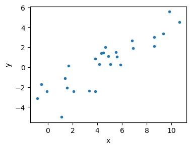

```python
plt.rcParams['figure.figsize'] = (4.0, 3.0)
plt.plot(x, y, '.');
plt.xlabel("x"); plt.ylabel("y");
```

As you might know, the strong assumptions in OLS make the calculation of the posterior algebraically solvable. This is convenient, as we can easily compute the exact posterior and compare our approximate results to it. The calculations are not especially hard to implement manually, but we will nevertheless let the `statsmodels` package do them for us.

```python
model = sm.OLS(y, sm.add_constant(x))
ols = model.fit()
```

The posterior, $p(a,b|x,y)$, is a 2D Gaussian with mean

```python
ols.params
```

```
array([-2.75994154,  0.69626281])
```

and covariance matrix

```python
ols.normalized_cov_params
```

```
array([[ 0.11651851, -0.01751249],
       [-0.01751249,  0.0038586 ]])
```

```python
np.sqrt(ols.normalized_cov_params.diagonal())
```

```
array([0.34134808, 0.06211765])
```

Below we codify this by storing frozen `st.norm` objects representing the 1D marginalized posteriors, and ellipses deliniating the 2D credible regions, for ease of comparison later.

```python
param_names = ['a', 'b']
```

```python
true_post = {'1D':{'a':st.norm(ols.params[0], np.sqrt(ols.normalized_cov_params[0,0])),
                   'b':st.norm(ols.params[1], np.sqrt(ols.normalized_cov_params[1,1]))},
             '2D':{'68.3':cr.cov_ellipse(ols.normalized_cov_params, center=ols.params, level=0.68268949),
                   '95.4':cr.cov_ellipse(ols.normalized_cov_params, center=ols.params, level=0.95449974)}
            }
```

### Laplace Approximation

In this excrutiatingly simple example, the true posterior is Gaussian, and so the Laplace Approximation should give us the exact posterior! Let's see.

Recall that to implement the LA, you will need to

1. find the maximum of the posterior, and
2. estimate the matrix of second derivatives of the log-posterior at that point.

For OLS, `statsmodels` effectively did this for us algebraically. Since that isn't an option in general, below you will use `scipy.optimize.minimize` to accomplish the same thing. First, we will need a function returning $-\ln p(a,b|x,y)$; minimizing this will accomplish (1) above.

```python
def minus_lnp(params, x, y):
    # return -ln(posterior) given params, a 1D np.array [a,b]
```

We also need a guess at the parameter values, for the minimizer to use as a starting point. You could choose something by inspection of the plot above. Or, being confident that the fitter will manage this problem well enough, we could just start at $(0,0)$, which is not a million miles away.

```python
guess = [0.0, 0.0]
```

Now we turn things over to `scipy`. If you're not familiar, there are a handful of algorithms that `minimize` can use. We'd like one that internally estimates and uses the second derivatives of the function being minimized, since it means we can just get those derivatives about the minimum from the fitter instead of estimating them ourselves. The default algorithm does this, though note that this is not true of all the options, and the specific method for accessing the derivatives varies (see the documentation for `minimize` for details).

```python
LA = minimize(minus_lnp, guess, args=(x,y))
LA
```

```
  message: Optimization terminated successfully.
  success: True
   status: 0
      fun: 43.40431004851482
        x: [-2.760e+00  6.963e-01]
      nit: 3
      jac: [ 0.000e+00  4.768e-07]
 hess_inv: [[ 1.165e-01 -1.751e-02]
            [-1.751e-02  3.859e-03]]
     nfev: 15
     njev: 5
```

The posterior mode is stored in `LA.x`, and should be *extremely* close to the algebraic solution.

```python
assert np.allclose(LA.x, ols.params)
```

The inverse-Hessian, which is the posterior covariance matrix of the parameters, as helpfully provided in `LA.hess_inv`, and shown above. It, too, should be extremely close to the OLS calculation.

```python
assert np.allclose(LA.hess_inv, ols.normalized_cov_params)
```

Let's go ahead and visualize the usual 2D credible regions.

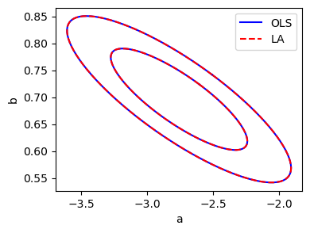

```python
plt.rcParams['figure.figsize'] = (4.0, 3.0)
plt.plot(true_post['2D']['68.3'][0], true_post['2D']['68.3'][1], '-', color='b', label='OLS');
plt.plot(true_post['2D']['95.4'][0], true_post['2D']['95.4'][1], '-', color='b');
cr.cov_ellipse(LA.hess_inv, center=LA.x, level=0.68268949, plot=plt, fmt='--', color='r', label="LA");
cr.cov_ellipse(LA.hess_inv, center=LA.x, level=0.95449974, plot=plt, fmt='--', color='r');
plt.xlabel("a"); plt.ylabel("b");
plt.legend();
```

## Approximate Bayesian Computation

Next, we turn to ABC. Below, you'll implement the simplest version of this algorithm:

1. Choose a set of summary statistics that encode important features of the data.
2. Choose a distance function providing a metric for comparing summary statistics computed from different data, and a distance threshold.
3. For many iterations,
- sample a set of parameters from the prior;
- simulate a mock data set from those parameters using the generative model;
- compute the summary statistics from those mock data;
- if the distance between that summary and the summary statistics computed on the real data is smaller than the threshold, accept the parameter sample.

Needless to say, this is not the most efficient version of ABC, but it will serve. However, there is an immediate, practical issue, namely that we chose infinite, uniform priors above in order to make the problem equivalent to OLS. Clearly we can't sample from the full interval $(-\infty,\infty)$. In any case, the credible regions above are tiny compared with the range of finite numbers that we can, in principle, draw from. So a naive implementation can be expected to take an exceptionally long time to produce even a single acceptable sample. (This is a good argument for choosing sensible priors, if you needed another one.)

We will inelegantly work around this issue by remembering that, for parameter estimation, we only really need to consider the prior over the region of parameter space where the posterior will be non-tiny. Seeing how we have an approximate posterior from LA, let's use it to sneakily redefine the functional bounds of the priors for this exercise. Truncating $p(a)$ and $p(b)$ at the 0.0001 and 0.9999 quantiles of their respective marginalized posteriors seems to work well in this case.

As we've done before, store the priors for $a$ and $b$ as frozen `scipy.stats` distributions in a dictionary.

```python
# priors = {'a':..., 'b':...}
```

To make it simpler to try out different summary statistics or distance metrics, we'll use classes and inheritance to package up reusable code. The cell below has just one method for you to complete, namely the one that performs the loop in the pseudocode above. **Do not** include an accept/reject step here (that is, accept all samples); instead, record the distance for each sample. That way, we can easily look at how the choice distance threshold affects our results later.

Also, try to make your code general enough that we can reuse it with another generative model and data set later on; that is, don't reference variables at global scope if they're stored in the `ABC` object already by its constructor.

```python
class ABC:
    def __init__(self, x, ytrue, priors):
        self.x = x
        self.y = ytrue
        self.s_true = self.summaries(x, ytrue)
        self.priors = priors
        self.param_names = [p for p in priors.keys()]
    # derived classes must define the following
    def summaries(self, x, y):
        # return summary statistics as a 1D np.array
        raise Exception('ABC::summaries should be defined by a deriving class')
    def distance(self, s1, s2):
        # return scalar distance between 2 sets of summary statistics
        raise Exception('ABC::distance should be defined by a deriving class')
    def simulate(self):
        # return a simulated 1D array y, given self.x and additional parameters arguments (with default values)
        raise Exception('ABC::simulate should be defined by a deriving class')
    # the important part
    def run(self, Nsim):
        self.samples = np.full((Nsim, len(self.param_names)), np.nan)
        self.distances = np.full(Nsim, np.nan)
        for i in range(Nsim):
            params = {p:self.priors[p].rvs() for p in self.param_names}
            ysim = self.simulate(**params)
            # compute summaries and distance from self.s_true
            # store params in the ith row of self.samples
            # store distance in the ith entry of self.distances
    # useful visualizations
    def distance_hist(self):
        plt.rcParams['figure.figsize'] = (4.0, 3.0)
        plt.hist(self.distances);
        plt.xlabel("d");
    def select_distances(self, eps):
        self.selection = np.flatnonzero(self.distances < eps)
        self.samples2 = self.samples[self.selection,:]
        print('Acceptance rate:', self.samples2.shape[0]/self.samples.shape[0], '(', self.samples2.shape[0], 'accepted samples )')
    def plot_acceptances(self, truth=None, truth_tri=None, size=8.0, show_rejects=True):
        plt.rcParams['figure.figsize'] = (size, size)
        n = len(self.param_names)
        fig = plt.figure()
        axes = []
        for i,p in enumerate(self.param_names):
            axes.append([])
            ax = fig.add_subplot(n, n, (i*n)+i+1)
            ax0 = ax
            ax.hist(self.samples2[:,i], density=True, label='ABC');
            if truth is not None:
                aa = np.linspace(*self.priors[p].ppf([0.0001,0.9999]), 100)
                ax.plot(aa, truth['1D'][p].pdf(aa), label='truth');
            if i==n-1:
                ax.set_xlabel(p);
            else:
                ax.get_xaxis().set_ticklabels([])
            ax.get_yaxis().set_ticklabels([])
            for j,q in enumerate(self.param_names):
                if j == i:
                    break
                ax = fig.add_subplot(n, n, (i*n)+j+1)
                axes[-1].append(ax)
                if show_rejects:
                    ax.plot(self.samples[:,j], self.samples[:,i], ',', color='C2');
                ax.plot(self.samples2[:,j], self.samples2[:,i], '.');
                if truth is not None:
                    for k in truth['2D'].keys():
                        ax.plot(truth['2D'][k][0], truth['2D'][k][1], color='C1', label='truth');
                if i==n-1:
                    ax.set_xlabel(q);
                else:
                    ax.get_xaxis().set_ticklabels([])
                if j==0:
                    ax.set_ylabel(p);
                else:
                    ax.get_yaxis().set_ticklabels([])
            axes[-1].append(ax0)
        if truth_tri is not None:
             cr.whist_triangle_plot(truth_tri, axes=axes, linecolor1D='C1', linecolor2D='C1', fill2D=False);
```